# R Notebook

```r
library(xlsx)
library(ggplot2)
library(forecast)
```

```r
housing <- read.xlsx("data_g5.xlsx", sheetName = "6.19 r")
```

```r
head(housing)
```

|  | Fecha | X..Viviendas |
| --- | --- | --- |
| 1 | 1990-01-01 | 19.8 |
| 2 | 1990-02-01 | 19.8 |
| 3 | 1990-03-01 | 19.7 |
| 4 | 1990-04-01 | 19.7 |
| 5 | 1990-05-01 | 19.3 |
| 6 | 1990-06-01 | 19.0 |

1. Plot the series and briefly comment on the characteristics you observe (stationarity, trend, seasonality, …).

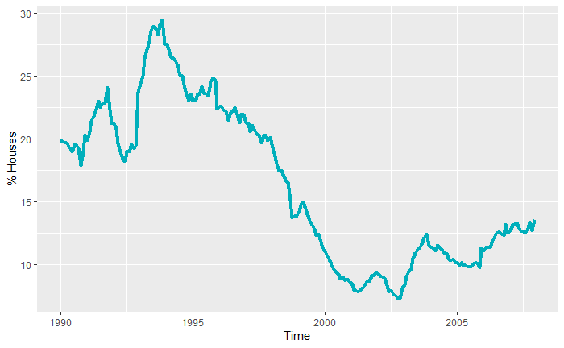

```r
ggplot(data = housing, aes(x = Fecha, y = X..Viviendas))+
  geom_line(color = "#00AFBB", size = 1.5) +
  labs(x = "Time", y = "% Houses")
```

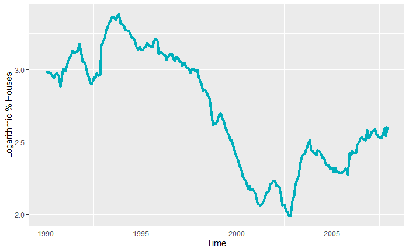

```r
#Logarithmic transformation
ggplot(data = housing, aes(x = Fecha, y = log(X..Viviendas)))+
  geom_line(color = "#00AFBB", size = 1.5) +
  labs(x = "Time", y = "Logarithmic % Houses")
```

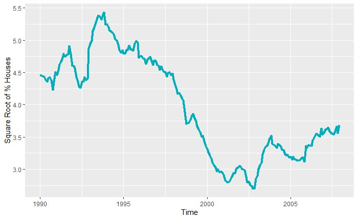

```r
#Square root transformation
ggplot(data = housing, aes(x = Fecha, y = sqrt(X..Viviendas)))+
  geom_line(color = "#00AFBB", size = 1.5) +
  labs(x = "Time", y = "Square Root of % Houses")
```

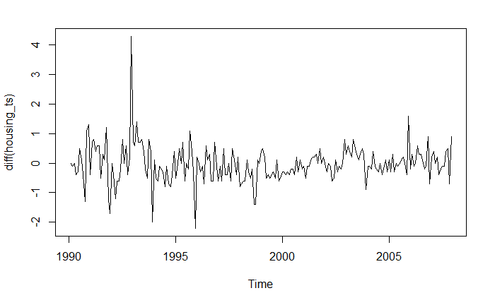

```r
housing_ts <- ts(housing[,2], frequency=12, start=c(1990,1))


#First order difference
plot(diff(housing_ts))
```

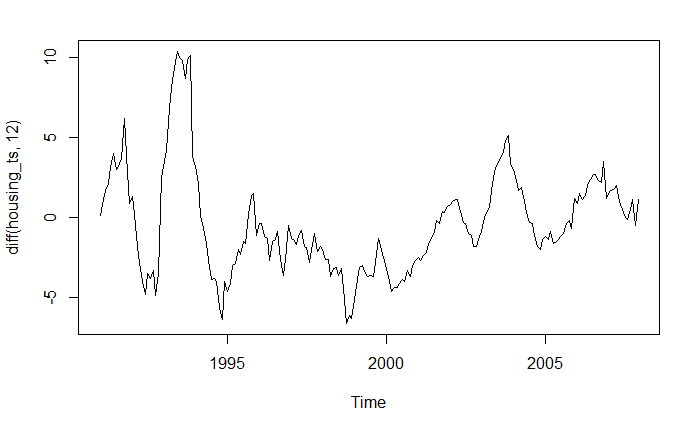

```r
#Seasonal difference
plot(diff(housing_ts, 12))
```

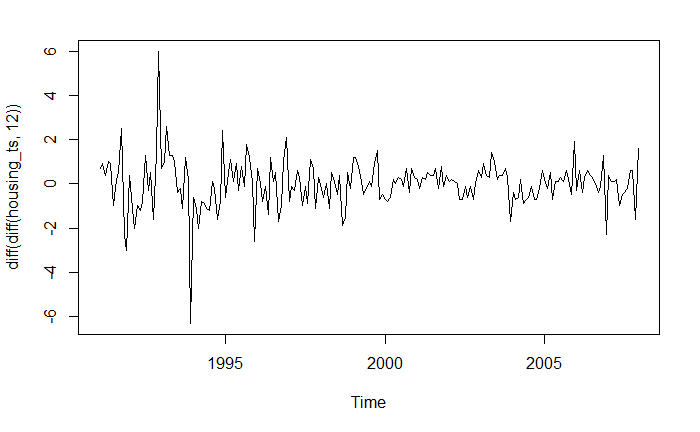

```r
#Second order difference
plot(diff(diff(housing_ts, 12)))
```

It is a non-stationaty Time Series, as there is a trend over time and we can see different patterns. There is a changing trend that had two major positive slopes between 1991 and 1993, but then the trend became negative until much later around the year 2002. After that, the trend looks to be going slowly up. This trend changed direction two times in this period of time.

It seems that there is no seasonality, as there is not a regularly repeating pattern related to quarters of the year, and the variability is decreasing, reducing the amount of change over time.

There is no evidence of any cyclic behaviour in the data.

```r
sd(housing_ts)
```

```
[1] 6.254621
```

```r
sd(diff(housing_ts))
```

```
[1] 0.621128
```

```r
sd(diff(housing_ts, 12))
```

```
[1] 3.267001
```

```r
sd(diff(diff(housing_ts, 12)))
```

```
[1] 1.093398
```

The standard deviation stops decreasing with one first order differentiation.

2. Obtain a plot of the decomposition of the series, using stl(). Use an additive decomposition or a multiplicative one, depending on your data. Use the function forecast() to forecast future values. Multiplicative decomposition is useful when the logarithmic transformation makes a difference in the appearance of your series and shows more constant variance. Does the remainder look like a white noise to you? White noise is just a group of independent, identically distributed variables, with zero mean and constant variance. Answer to this point just visually or plot the ACF and PACF of the remainder part.

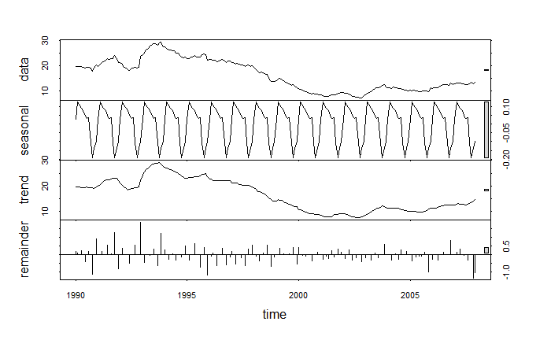

```r
stl.housing <- stl(housing_ts, t.window=5, s.window="periodic", robust=TRUE)
plot(stl.housing)
```

The bar on the seasonal panel is huge compared with the one on the data panel, indicating a lack of seasonal influence. On the other hand, the bar on the trend panel is roughly the same size as the first one, indicating that the variation attributed to the trend is much higher than the seasonal component. The residuals represent much more stochastic fluctuations than the seasonal panel, indicating that it is the second most important component.

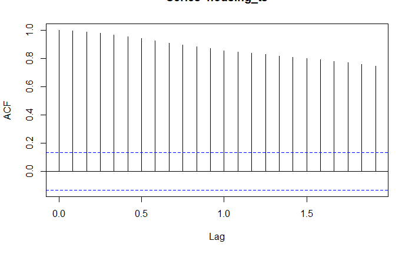

```r
acf(housing_ts)
```

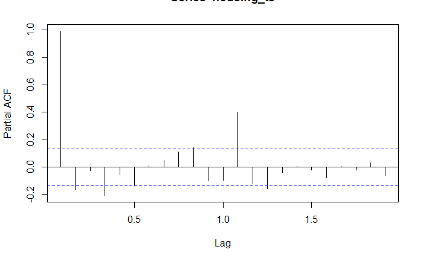

```r
pacf(housing_ts)
```

```r
forecast(housing_ts)
```

|  | Point Forecast | Lo 80 | Hi 80 | Lo 95 | Hi 95 |
| --- | --- | --- | --- | --- | --- |
| Jan 2008 | 13.62630 | 12.992139 | 14.26046 | 12.656436 | 14.59616 |
| Feb 2008 | 13.74525 | 12.807597 | 14.68290 | 12.311235 | 15.17926 |
| Mar 2008 | 13.84042 | 12.601563 | 15.07928 | 11.945751 | 15.73509 |
| Apr 2008 | 13.91657 | 12.381649 | 15.45149 | 11.569110 | 16.26403 |
| May 2008 | 13.97750 | 12.153889 | 15.80111 | 11.188528 | 16.76647 |
| Jun 2008 | 14.02625 | 11.922663 | 16.12983 | 10.809092 | 17.24340 |
| Jul 2008 | 14.06525 | 11.691060 | 16.43944 | 10.434239 | 17.69627 |
| Aug 2008 | 14.09646 | 11.461219 | 16.73170 | 10.066207 | 18.12671 |
| Sep 2008 | 14.12143 | 11.234584 | 17.00828 | 9.706380 | 18.53648 |
| Oct 2008 | 14.14141 | 11.012100 | 17.27072 | 9.355545 | 18.92727 |

[output cut: 14 more lines]